# Digital produktion och informationsarkitektur

KOMC36: Projektledning i digitala miljöer HT24

nils.holmberg@isk.lu.se

## Course literature

[figure not shown]

Morville, Rosenfeld, and Arango (2015)

[figure not shown]

Ebook downloaded from:  
https://webflow.com/

## Lectures and workshops

#### Lecture, nov 28

- Information architecture
- Web design, User interface

#### Workshop, dec 4 (zoom)

- Mermaid (ChatGPT)
- Webflow, Figma

## Communication project

- Strategy
- Scope
- Structure
- Skeleton
- Surface

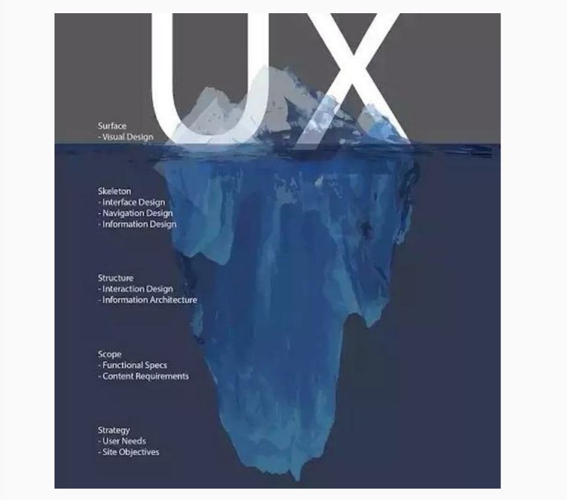

## Project cases

[figure not shown]

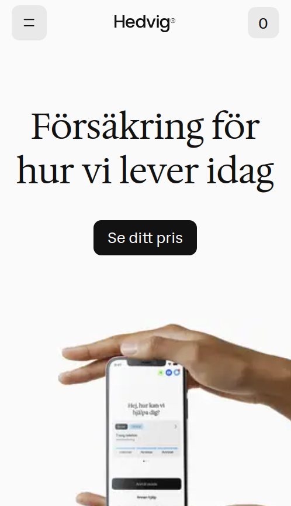

[figure not shown]

## Research: Foundations of IA

#### Information architecture, Ch. 11

- Framework: Context, content, and user-centered research.
- Users: Define, recruit, and conduct sessions effectively.
- Content analysis: Inventory, structure, and gaps.
- Advocacy: Research ensures evidence-based decisions.

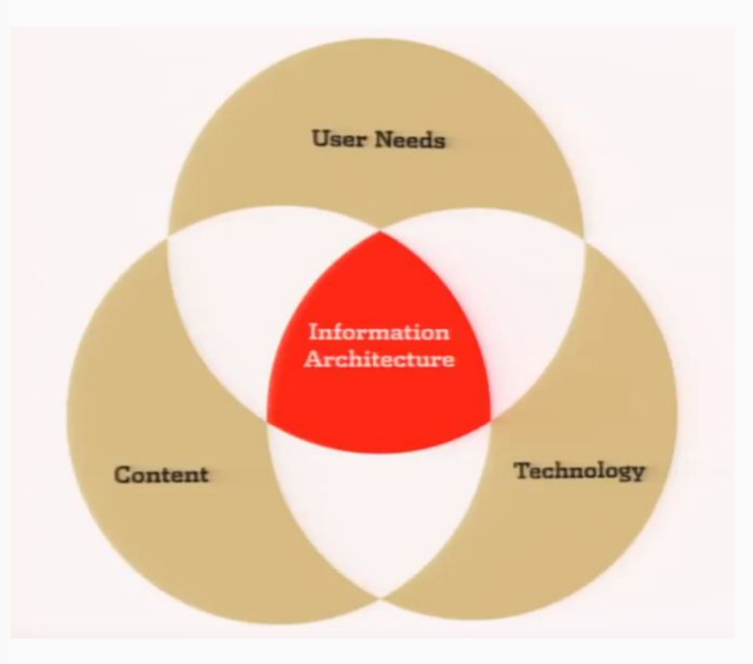

## Crafting an IA Strategy

#### Information architecture, Ch. 12

- Strategy: A roadmap aligning IA with goals.
- Transition: Turning research insights into strategic actions.
- Deliverables: Reports, plans, and presentations.
- Challenges: Defending and adapting IA strategies.

## What Problems Does Information Architecture Solve?

#### Information architecture, Ch. 1

- Hello, iTunes: A case study of complexity and user experience.
- Challenges: Poor navigation, findability, and usability.
- Enter IA: Structuring and organizing for clarity and effectiveness.
- Solutions: Aligning user needs with system structure.

## Defining Information Architecture

#### Information architecture, Ch. 2

- Definitions: IA organizes and structures content for usability.
- Visibility: Good IA is often invisible but essential.
- Best Practices: Balancing creativity with functionality.
- Goals: Enhance user experience through thoughtful design.

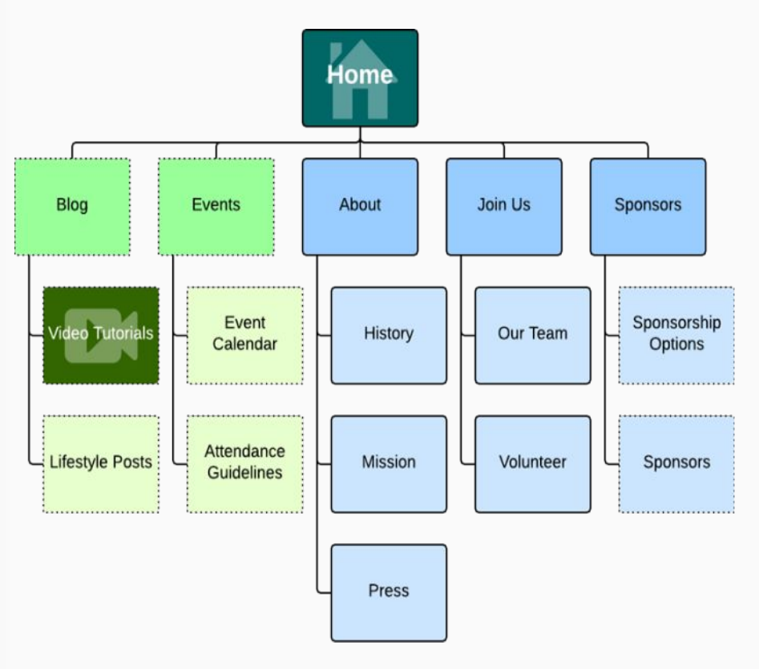

## Designing for Finding

#### Information architecture, Ch. 3

- Simple Models Fail: Real needs demand nuanced approaches.
- Information Needs: Anticipating what users seek.
- User Behavior: Search, browse, and discovery patterns.
- Research: Methods to understand users’ search strategies.

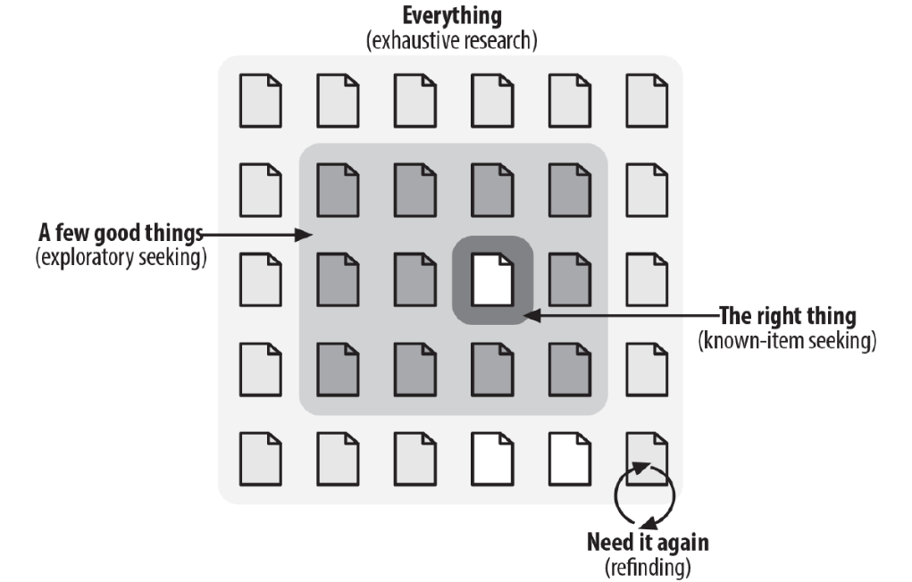

## Designing for Understanding

#### Information architecture, Ch. 4

- Sense of Place: Helping users navigate digital spaces confidently.
- Real-World Inspiration: Learning from physical architecture.
- Organizing Principles: Clarity through structure and hierarchy.
- Modularity: Scalable and flexible systems for long-term usability.

## Anatomy of Information Architecture

#### Information architecture, Ch. 5

- Visualizing IA: Diagrams to map structure and relationships.
- Top-Down vs. Bottom-Up: Strategic vs. user-driven IA.
- Invisible IA: Systems users experience but don’t see.
- Components: Content, context, and users as building blocks.

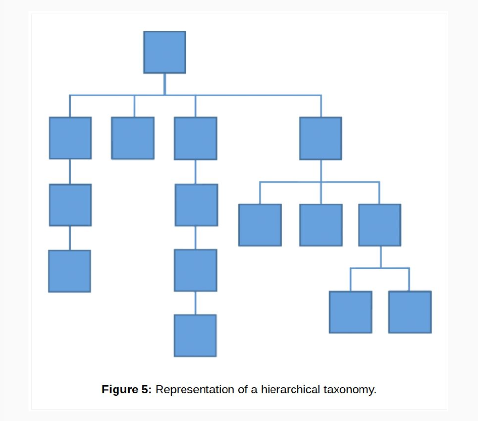

## Building Organization Systems

#### Information architecture, Ch. 6

- Challenges: Overcoming complexity and ambiguity.
- Schemes: Topical, chronological, and audience-based methods.
- Structures: Hierarchies, networks, and databases.
- Social Classification: Crowdsourced tagging and folksonomies.

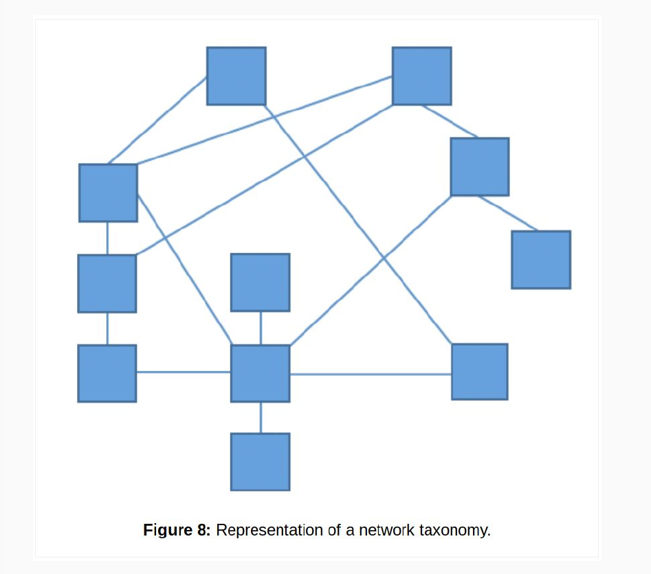

## Crafting Labeling Systems

#### Information architecture, Ch. 7

- Importance: Labels help users find and understand content.
- Varieties: Textual, icon-based, and hybrid labels.
- Functions: Labels as navigational headings and descriptors.
- Design: Clear, concise, and consistent language.
- How is this implemented in client organization?

## Designing Navigation Systems

#### Information architecture, Ch. 8

- Types: Global (embedded), local (supplemental), and contextual navigation.
- Placemaking: Helping users orient themselves within the system.
- Flexibility: Supporting diverse user needs and paths.
- Advanced Approaches: Breadcrumbs, mega menus, and filters.
- How is this implemented in client organization?

## Designing Search Systems

#### Information architecture, Ch. 9

- Necessity: Determining if search adds value to the experience.
- Anatomy: Indexing, algorithms, and query builders.
- Presenting Results: Sorting, filters, and relevance ranking.
- Search Interface: Intuitive input fields and clear feedback.
- How is this implemented in client organization?

## Thesauri, Controlled Vocabularies, and Metadata

#### Information architecture, Ch. 10

- Metadata: Structuring data for discoverability and context.
- Controlled Vocabularies: Standardizing terminology.
- Semantic Relationships: Hierarchies, synonyms, and cross-references.
- Faceted Classification: Multi-dimensional sorting for user flexibility.
- How is this implemented in client organization?

## Design and Documentation

#### Information architecture, Ch. 13

- Visual tools: Sitemaps, wireframes, and content maps.
- Controlled vocabularies for consistent navigation.
- Collaborative design: Unifying teams and processes.
- Style: Comprehensive IA documentation and guidelines.

## Break!

## Digital production

- Strategy
- Scope
- Structure
- Skeleton
- Surface

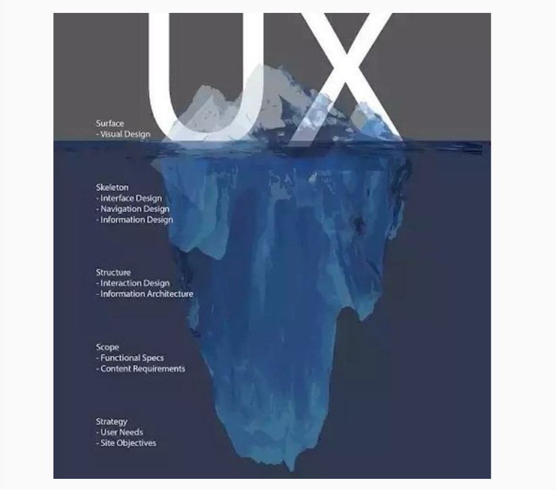

## Strategy

#### Web design process

- Aligns design with overarching web goals and user experience.
- Defines purpose and key outcomes for the interface.
- Bridges user needs and technical constraints.
- Establishes a clear design direction for the project.
- Guides consistency across the entire design process.

## Strategy, User Needs

#### Web design process

- Focuses on understanding and addressing user pain points.
- Ensures the interface meets user expectations and enhances usability.
- Prioritizes features and experiences that provide real value to users.
- Maps user personas to tailor interactions to diverse needs.
- Creates solutions that solve practical problems for the target audience.

[figure not shown]

## Strategy, Site Objectives

#### Web design process

- Identifies measurable outcomes for the site.
- Aligns navigation and content with strategic priorities.
- Focuses on user retention and goal completion.
- Builds consistency in design to enhance usability.
- Lays the foundation for feature prioritization.

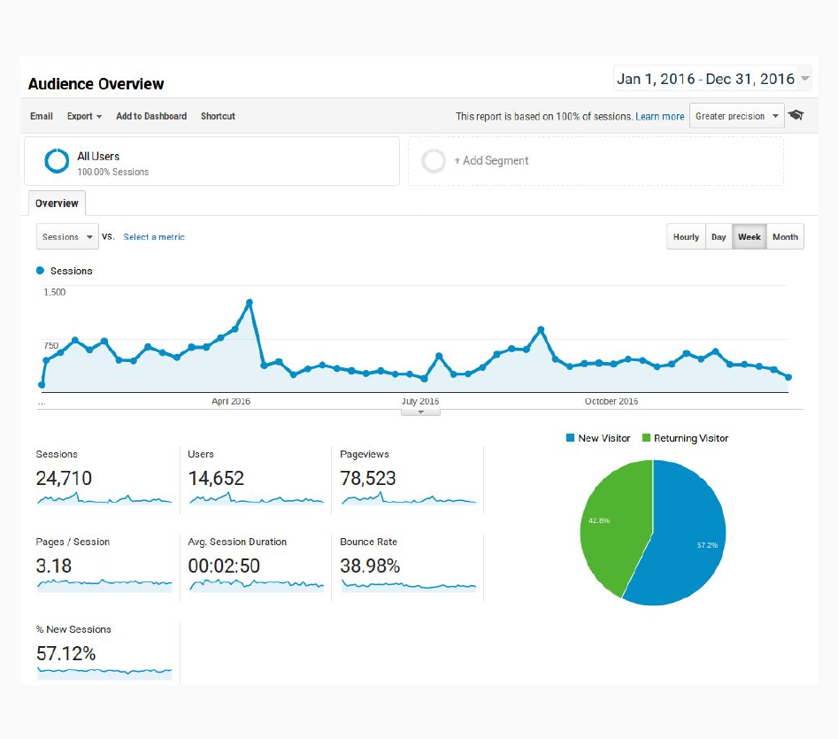

## Scope

#### Web design process

- Defines project boundaries and deliverables.
- Outlines core functionalities and content inclusions.
- Maps client needs to actionable tasks.
- Ensures design aligns with technical feasibility.
- Prevents scope creep through structured planning.

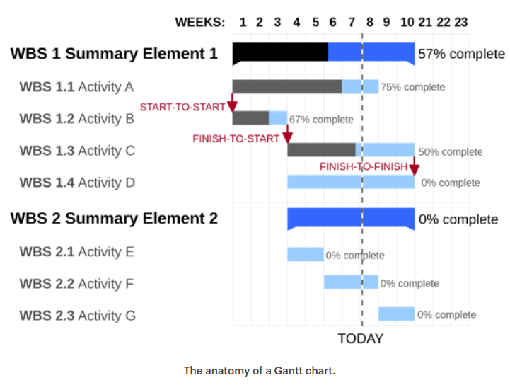

## Scope, Functional Specs

#### Web design process

- Details required features like forms and interactivity.
- Specifies integrations like APIs or third-party tools.
- Outlines backend requirements for user actions.
- Includes accessibility and performance benchmarks.
- Provides a roadmap for development teams.

## Scope, Content Requirements

#### Web design process

- Defines text, images, and multimedia needs.
- Ensures content aligns with branding and tone.
- Establishes placeholders for missing assets.
- Balances aesthetic design with functional clarity.
- Sets priorities for critical versus optional content.

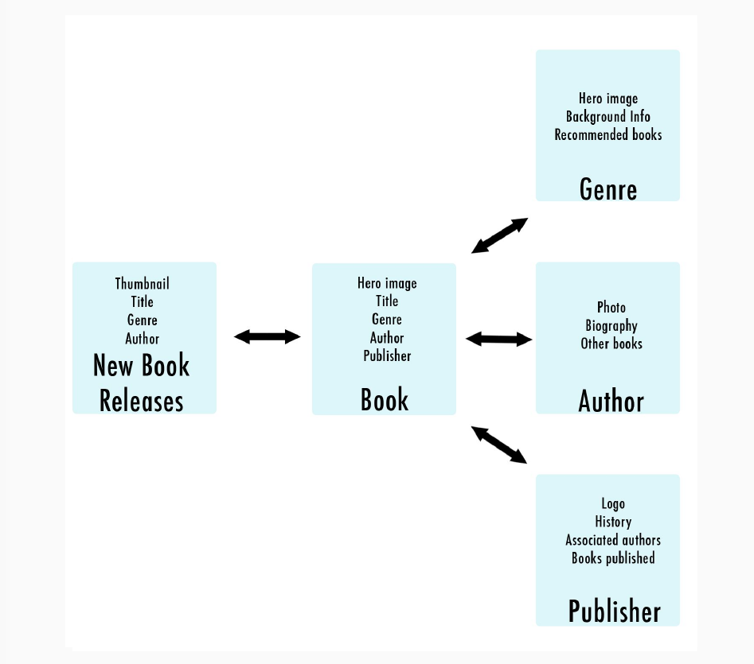

## Structure

#### Web design process

- Framework organizing content for usability and flow.
- Prioritizes content-first design principles.
- Balances simplicity with comprehensive coverage.
- Provides visual consistency for user interactions.
- Lays groundwork for navigation and information hierarchy.

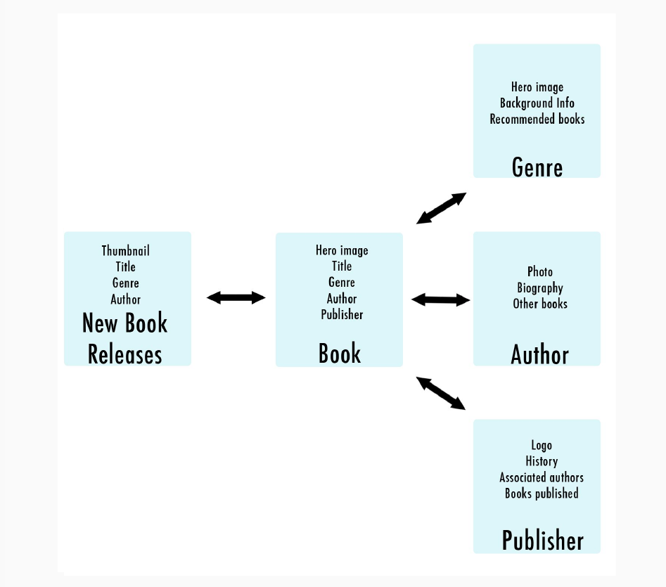

## Structure, Interaction Design

#### Web design process

- Plans responsive buttons, forms, and navigation links.
- Designs logical user flows for task completion.
- Prioritizes accessibility and error prevention.
- Enhances engagement with meaningful feedback loops.
- Focuses on intuitive click and touch interactions.

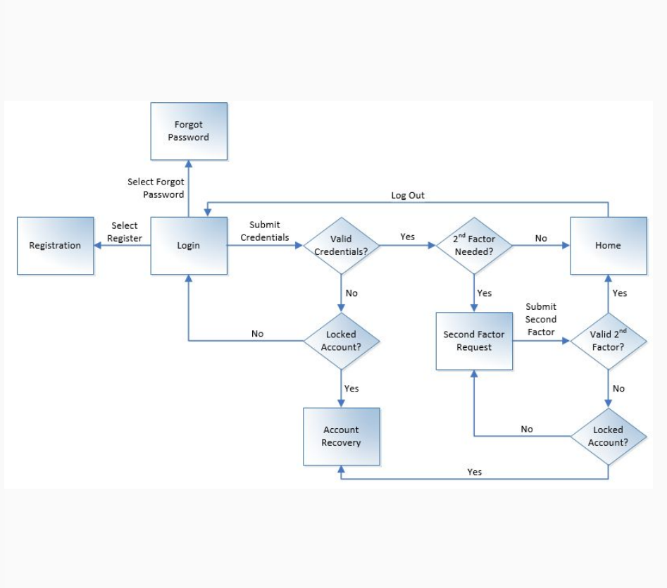

## Structure, Information Architecture

#### Web design process

- Creates clear sitemaps for navigation planning.
- Groups content logically to guide user journeys.
- Balances user goals with business objectives.
- Supports scalability for future site expansion.
- Aligns with SEO best practices for discoverability.

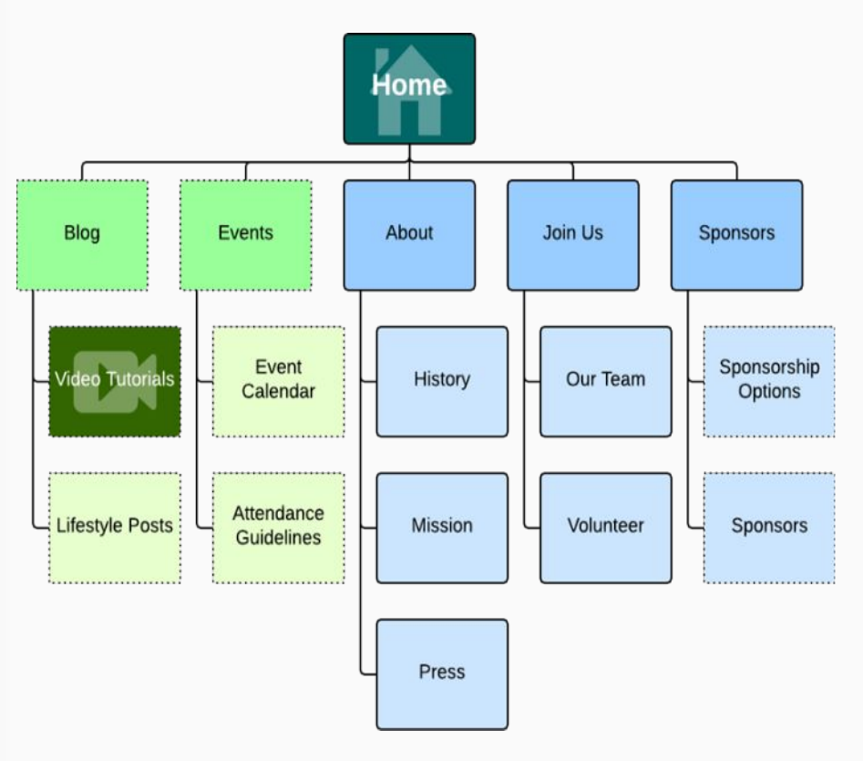

## Skeleton

#### Web design process

- Translates structure into low-fidelity wireframes.
- Lays out visual hierarchy and interactive zones.
- Ensures functional clarity before visual design.
- Identifies gaps or redundancies in content.
- Serves as a blueprint for final design stages.

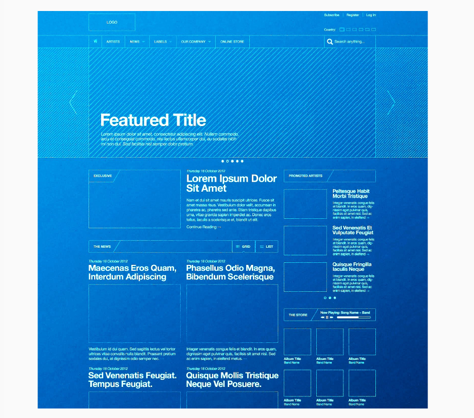

## Skeleton, Interface Design

#### Web design process

- Integrates consistent graphics, icons, and images.
- Balances text blocks with visual elements.
- Prioritizes forms and buttons for user interaction.
- Creates alignment across reusable UI components.
- Tests interface clarity with early user feedback.

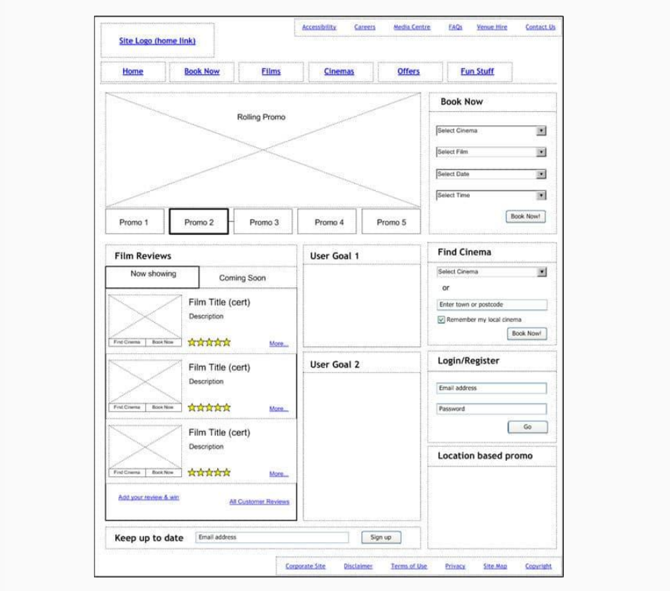

## Skeleton, Navigation Design

#### Web design process

- Plans global menus for primary navigation.
- Includes local menus for contextual navigation.
- Structures breadcrumb trails to enhance orientation.
- Optimizes for responsive design across devices.
- Balances depth and breadth in navigation hierarchy.

[figure not shown]

## Skeleton, Information Design

#### Web design process

- Organizes data into readable, scannable formats.
- Uses layout to highlight critical information.
- Ensures consistency in presenting similar data.
- Incorporates charts and tables where necessary.
- Balances text with visual emphasis for clarity.

## Surface

#### Web design process

- Represents the final layer of design aesthetics.
- Creates emotional connections through visual appeal.
- Focuses on user perception and brand alignment.
- Brings all design layers into a cohesive whole.
- Adds polish for a professional, usable product.

[figure not shown]

## Surface, Visual Design

#### Web design process

- Defines font pairings for readability and style.
- Establishes a harmonious color palette.
- Balances visual hierarchy for user attention.
- Ensures consistent iconography and button styling.
- Aligns visuals with accessibility standards.

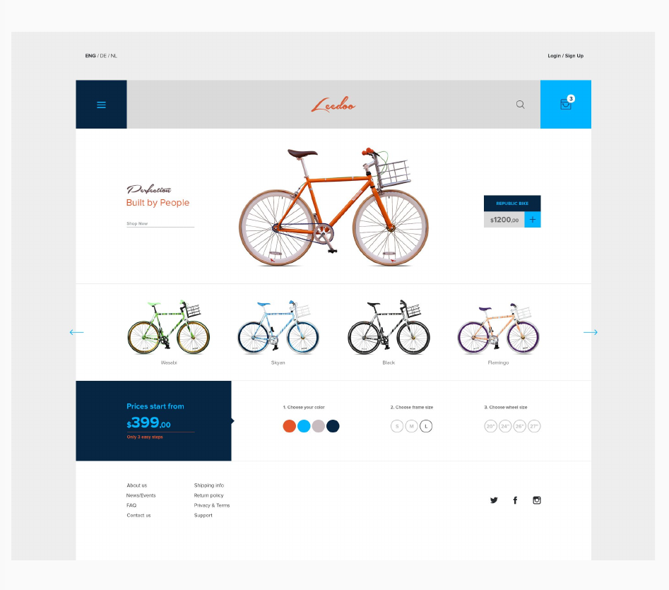

## Final testing and review

#### Web design process

- Validates functionality across browsers and devices.
- Tests interactions, forms, and user flows for usability.
- Ensures alignment with business and user goals.
- Fixes bugs and optimizes performance metrics.
- Prepares the site for seamless deployment.

## Product launch

#### Web design process

- Executes the go-live strategy with a detailed plan.
- Communicates launch with stakeholders and users.
- Monitors performance metrics post-launch.
- Addresses immediate user feedback and issues.
- Celebrates and transitions to maintenance mode.

## Mermaid

#### Digital production tools

- Visualizes design processes with flowcharts.
- Simplifies complex sitemaps and user flows.
- Creates interactive diagrams for stakeholder buy-in.
- Documents architecture changes for teams.
- Integrates easily into collaborative tools.

## Webflow, Figma

#### Digital production tools

- Enables rapid prototyping with responsive designs.
- Streamlines collaboration between designers and developers.
- Balances visual creativity with technical functionality.
- Tests user experiences with interactive components.
- Bridges the gap from concept to deployment seamlessly.

## Next steps

#### Workshop on zoom, dec 4

- Sitemaps, Flow charts: https://mermaid.live/
- Interface design: https://webflow.com/, https://www.figma.com

#### References

Morville, Peter, Louis B Rosenfeld, and Jorge Arango. 2015. *Information Architecture for the Web and Beyond*. O’Reilly.

https://canvas.education.lu.se/courses/28874